# Challenge Results: Calculate and Predict CLV per Region

Using the 'superstore_final_dataset.csv', from Kaggle, we will implement the following analysis:

- Load and view dataset
- Perform an initial exploratory data analysis
- Perform feature engineering to groupby relevant features and calculate Customer Lifetime Value
- Create train, validate and test datasets
- Select an appropriate regession model using CLV as the target variable
- Run cross validation and a hyperparameter grid search to faciliate optimising the model training
- Test predictive model against the test dataset

# Load and View Dataset

```python
import pandas as pd
import warnings

# Ignore all warning messages
warnings.filterwarnings('ignore')

# Load the dataset
df = pd.read_csv('superstore_final_dataset.csv', encoding='latin1')

# check it out...
df
```

|  | Row_ID | Order_ID | Order_Date | Ship_Date | Ship_Mode | Customer_ID | Customer_Name | Segment | Country | City | State | Postal_Code | Region | Product_ID | Category | Sub_Category | Product_Name | Sales |
| --- | --- | --- | --- | --- | --- | --- | --- | --- | --- | --- | --- | --- | --- | --- | --- | --- | --- | --- |
| 0 | 1 | CA-2017-152156 | 8/11/2017 | 11/11/2017 | Second Class | CG-12520 | Claire Gute | Consumer | United States | Henderson | Kentucky | 42420.0 | South | FUR-BO-10001798 | Furniture | Bookcases | Bush Somerset Collection Bookcase | 261.9600 |
| 1 | 2 | CA-2017-152156 | 8/11/2017 | 11/11/2017 | Second Class | CG-12520 | Claire Gute | Consumer | United States | Henderson | Kentucky | 42420.0 | South | FUR-CH-10000454 | Furniture | Chairs | Hon Deluxe Fabric Upholstered Stacking Chairs,... | 731.9400 |
| 2 | 3 | CA-2017-138688 | 12/6/2017 | 16/06/2017 | Second Class | DV-13045 | Darrin Van Huff | Corporate | United States | Los Angeles | California | 90036.0 | West | OFF-LA-10000240 | Office Supplies | Labels | Self-Adhesive Address Labels for Typewriters b... | 14.6200 |
| 3 | 4 | US-2016-108966 | 11/10/2016 | 18/10/2016 | Standard Class | SO-20335 | Sean O Donnel | Consumer | United States | Fort Lauderdale | Florida | 33311.0 | South | FUR-TA-10000577 | Furniture | Tables | Bretford CR4500 Series Slim Rectangular Table | 957.5775 |
| 4 | 5 | US-2016-108966 | 11/10/2016 | 18/10/2016 | Standard Class | SO-20335 | Sean O Donnel | Consumer | United States | Fort Lauderdale | Florida | 33311.0 | South | OFF-ST-10000760 | Office Supplies | Storage | Eldon Fold N Roll Cart System | 22.3680 |
| ... | ... | ... | ... | ... | ... | ... | ... | ... | ... | ... | ... | ... | ... | ... | ... | ... | ... | ... |
| 9795 | 9796 | CA-2017-125920 | 21/05/2017 | 28/05/2017 | Standard Class | SH-19975 | Sally Hughsby | Corporate | United States | Chicago | Illinois | 60610.0 | Central | OFF-BI-10003429 | Office Supplies | Binders | Cardinal HOLDit! Binder Insert Strips,Extra St... | 3.7980 |
| 9796 | 9797 | CA-2016-128608 | 12/1/2016 | 17/01/2016 | Standard Class | CS-12490 | Cindy Schnelling | Corporate | United States | Toledo | Ohio | 43615.0 | East | OFF-AR-10001374 | Office Supplies | Art | BIC Brite Liner Highlighters, Chisel Tip | 10.3680 |
| 9797 | 9798 | CA-2016-128608 | 12/1/2016 | 17/01/2016 | Standard Class | CS-12490 | Cindy Schnelling | Corporate | United States | Toledo | Ohio | 43615.0 | East | TEC-PH-10004977 | Technology | Phones | GE 30524EE4 | 235.1880 |
| 9798 | 9799 | CA-2016-128608 | 12/1/2016 | 17/01/2016 | Standard Class | CS-12490 | Cindy Schnelling | Corporate | United States | Toledo | Ohio | 43615.0 | East | TEC-PH-10000912 | Technology | Phones | Anker 24W Portable Micro USB Car Charger | 26.3760 |
| 9799 | 9800 | CA-2016-128608 | 12/1/2016 | 17/01/2016 | Standard Class | CS-12490 | Cindy Schnelling | Corporate | United States | Toledo | Ohio | 43615.0 | East | TEC-AC-10000487 | Technology | Accessories | SanDisk Cruzer 4 GB USB Flash Drive | 10.3840 |

9800 rows × 18 columns

# Perform a Basic Exploratory Data Analysis

```
Summary Statistics:
            Row_ID   Postal_Code         Sales
count  9800.000000   9789.000000   9800.000000
mean   4900.500000  55273.322403    230.769059
std    2829.160653  32041.223413    626.651875
min       1.000000   1040.000000      0.444000
25%    2450.750000  23223.000000     17.248000
50%    4900.500000  58103.000000     54.490000
75%    7350.250000  90008.000000    210.605000
max    9800.000000  99301.000000  22638.480000

Unique Values and Frequency Distributions:

Order_ID:
CA-2018-100111    14
CA-2018-157987    12
CA-2017-165330    11
US-2017-108504    11
CA-2017-105732    10
                  ..
US-2015-105151     1
CA-2015-142839     1
CA-2016-132948     1
CA-2018-161739     1
CA-2018-148138     1
Name: Order_ID, Length: 4922, dtype: int64

Order_Date:
5/9/2017      38
10/11/2017    35
2/12/2018     34
1/12/2018     34
9/12/2018     33
              ..
17/10/2016     1
16/03/2015     1
24/06/2015     1
9/11/2017      1
13/06/2015     1
Name: Order_Date, Length: 1230, dtype: int64
```

[output cut: 192 more lines]

```
Ship_Mode         0
Customer_ID       0
Customer_Name     0
Segment           0
Country           0
City              0
State             0
Postal_Code      11
Region            0
Product_ID        0
Category          0
Sub_Category      0
Product_Name      0
Sales             0
dtype: int64
```

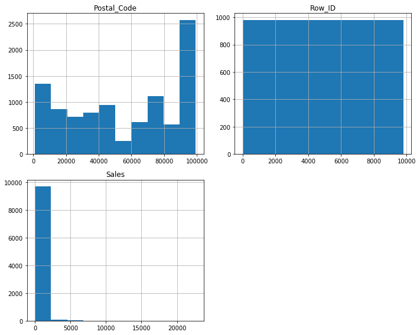

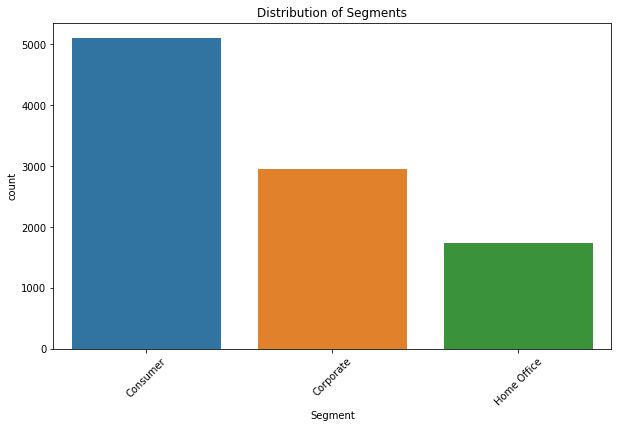

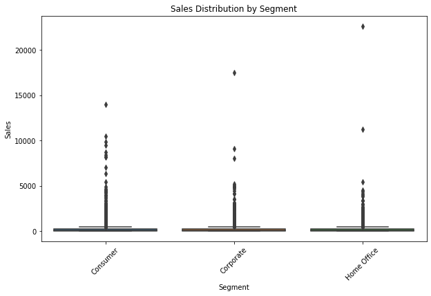

```python
import matplotlib.pyplot as plt
import seaborn as sns

# 1. Summary Statistics
print("Summary Statistics:")
print(df.describe())  # Summary statistics for numerical features
print("\nUnique Values and Frequency Distributions:")
for col in df.columns:
    if df[col].dtype == 'object':  # Check if the column is categorical
        print(f"\n{col}:")
        print(df[col].value_counts())  # Frequency distribution for categorical features

# 2. Missing Values
print("\nMissing Values:")
print(df.isnull().sum())  # Count missing values for each column

# 3. Data Visualization
# Histograms for numerical features
df.hist(figsize=(10, 8))
plt.tight_layout()
plt.show()

# Bar plots for categorical features
plt.figure(figsize=(10, 6))
sns.countplot(x='Segment', data=df)
plt.title('Distribution of Segments')
plt.xticks(rotation=45)
plt.show()

# Box plot for numerical features
plt.figure(figsize=(10, 6))
sns.boxplot(x='Segment', y='Sales', data=df)
plt.title('Sales Distribution by Segment')
plt.xticks(rotation=45)
plt.show()
```

# Feature Engineering

Create CLV target variable and assemble a dataset for data and predictive analysis

We are interested in creating a predictive algortihm for geographic locations, in this instance for "State". Hence we'll calculate CLV by deriving variables for Customer Tenure, Frequency of Purchases and Order Value. We'll then drop these feartures and see if CLV can be predicted by geographical location, hence allow us to consider scenario options for forecasting marketing spend, and the return, in different locations.

```python
# First, convert Order_Date and Ship_Date columns to datetime objects
df['Order_Date'] = pd.to_datetime(df['Order_Date'])
df['Ship_Date'] = pd.to_datetime(df['Ship_Date'])

# We're aiming to create a predictive algorithm for CLV by 'Customer_ID', 'Segment', 'Region', 'State'
# Hence we need to calculate CLV by that grouping, so we can use CLV as our target training metric
# First we will assemble the dataset from the original superstore dataset:

# Calculate customer tenure (time between first purchase date and last purchase date)
customer_tenure = df.groupby(['Customer_ID', 'Segment', 'Region', 'State'])['Order_Date'].agg(lambda x: (x.max() - x.min()).days)

# Calculate frequency of purchases (number of orders per customer)
frequency_of_purchases = df.groupby(['Customer_ID', 'Segment', 'Region', 'State'])['Order_ID'].nunique()

# Calculate average order value (total sales amount divided by number of orders)
average_order_value = df.groupby(['Customer_ID', 'Segment', 'Region', 'State'])['Sales'].sum() / df.groupby(['Customer_ID', 'Segment', 'Region', 'State'])['Order_ID'].nunique()

# Combine the calculated metrics into a DataFrame
clv_data = pd.DataFrame({
    'Customer_Tenure': customer_tenure,
    'Frequency_of_Purchases': frequency_of_purchases,
    'Average_Order_Value': average_order_value
})

# Now we will Calculate the CLV approximation for the 'Customer_ID', 'Segment', 'Region' grouping

# For simplicity, let's assume that the customer's lifetime is represented by their tenure
# CLV = Average_Order_Value * Frequency_of_Purchases * Customer_Tenure
clv_data['CLV'] = clv_data['Average_Order_Value'] * clv_data['Frequency_of_Purchases'] * clv_data['Customer_Tenure']

# Print the calculated CLV
clv_data
```

| Customer_ID | Segment | Region | State | Customer_Tenure | Frequency_of_Purchases | Average_Order_Value | CLV |
| --- | --- | --- | --- | --- | --- | --- | --- |
| AA-10315 | Consumer | Central | Minnesota | 0 | 1 | 374.480 | 0.000 |
|  |  |  | Texas | 0 | 1 | 4406.072 | 0.000 |
|  |  | East | New York | 0 | 1 | 29.500 | 0.000 |
|  |  | West | California | 376 | 2 | 376.754 | 283319.008 |
| AA-10375 | Consumer | Central | Nebraska | 0 | 1 | 178.370 | 0.000 |
| ... | ... | ... | ... | ... | ... | ... | ... |
| ZC-21910 | Consumer | West | Washington | 0 | 1 | 1549.770 | 0.000 |
| ZD-21925 | Consumer | Central | Indiana | 0 | 1 | 331.080 | 0.000 |
|  |  | South | Florida | 0 | 1 | 839.944 | 0.000 |
|  |  |  | Tennessee | 0 | 1 | 16.720 | 0.000 |
|  |  | West | California | 1167 | 2 | 153.100 | 357335.400 |

4008 rows × 4 columns

```python
# drop the rows where we are not able to calculate Customer_Tenure,
# hence CLV, due to insufficient purchase history data in the dataset

clv_data_filtered = clv_data[clv_data['Customer_Tenure'] != 0]

clv_data_filtered
```

| Customer_ID | Segment | Region | State | Customer_Tenure | Frequency_of_Purchases | Average_Order_Value | CLV |
| --- | --- | --- | --- | --- | --- | --- | --- |
| AA-10315 | Consumer | West | California | 376 | 2 | 376.754000 | 283319.008 |
| AA-10375 | Consumer | West | California | 186 | 2 | 25.396000 | 9447.312 |
| AA-10645 | Consumer | West | California | 399 | 2 | 694.702500 | 554372.595 |
| AB-10060 | Home Office | West | Washington | 631 | 2 | 1306.964000 | 1649388.568 |
| AB-10105 | Consumer | Central | Texas | 664 | 2 | 570.689000 | 757874.992 |
| ... | ... | ... | ... | ... | ... | ... | ... |
| YS-21880 | Corporate | West | California | 861 | 3 | 631.561333 | 1631322.924 |
| ZC-21910 | Consumer | Central | Illinois | 118 | 2 | 194.029000 | 45790.844 |
|  |  |  | Texas | 319 | 2 | 882.794000 | 563222.572 |
|  |  | West | California | 789 | 2 | 470.241000 | 742040.298 |
| ZD-21925 | Consumer | West | California | 1167 | 2 | 153.100000 | 357335.400 |

720 rows × 4 columns

```python
# Count the number of rows where the value in 'column_name' is 0
count_zeros = (clv_data_filtered['CLV'] == 0).sum()
print(count_zeros)
```

```
0
```

# Redo Exploratory Data Analysis on our derived dataset

Do we have some meaningful features?

```
       Customer_Tenure  Frequency_of_Purchases  Average_Order_Value  \
count       720.000000              720.000000           720.000000
mean        547.594444                2.269444           456.308706
std         348.686974                0.575010           584.537055
min           1.000000                2.000000             2.365500
25%         263.000000                2.000000           107.485250
50%         491.000000                2.000000           277.700000
75%         823.250000                2.000000           562.886125
max        1373.000000                6.000000          6861.749000

                CLV
count  7.200000e+02
mean   5.768720e+05
std    9.253204e+05
min    3.307360e+02
25%    7.806003e+04
50%    2.683933e+05
75%    6.715979e+05
max    1.006794e+07

Check for missing values:
Customer_ID               0
Segment                   0
Region                    0
State                     0
Customer_Tenure           0
Frequency_of_Purchases    0
Average_Order_Value       0
CLV                       0
dtype: int64
```

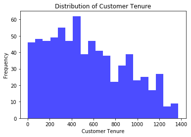

```
Segment Counts:
Consumer       365
Corporate      219
Home Office    136
Name: Segment, dtype: int64

Region Counts:
West       331
East       172
Central    159
South       58
Name: Region, dtype: int64
```

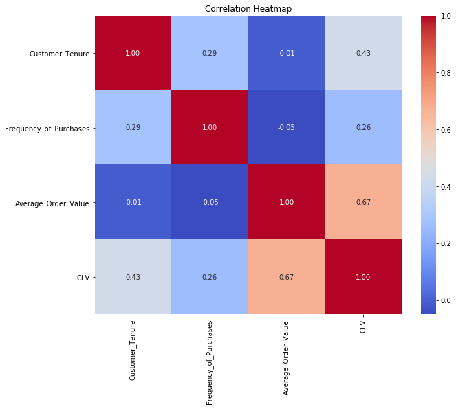

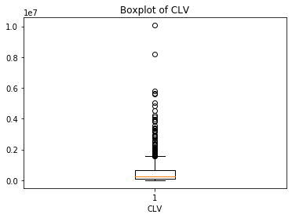

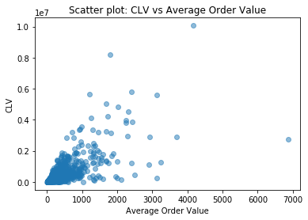

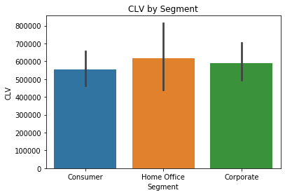

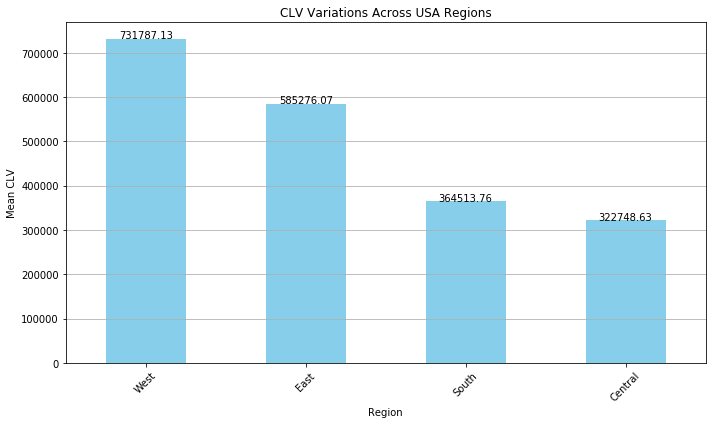

```python
df = clv_data_filtered.reset_index()

# Summary statistics
summary_stats = df.describe()
print(summary_stats)

# Missing values
missing_values = df.isnull().sum()
print("\nCheck for missing values:")
print(missing_values)

# Plot histograms
plt.hist(df['Customer_Tenure'], bins=20, color='blue', alpha=0.7)
plt.xlabel('Customer Tenure')
plt.ylabel('Frequency')
plt.title('Distribution of Customer Tenure')
plt.show()

# Count of categorical variables
segment_counts = df['Segment'].value_counts()
region_counts = df['Region'].value_counts()

print("Segment Counts:")
print(segment_counts)
print("\nRegion Counts:")
print(region_counts)

# Correlation matrix
plt.figure(figsize=(10, 8))
sns.heatmap(df.corr(), annot=True, cmap='coolwarm', fmt='.2f')
plt.title('Correlation Heatmap')
plt.show()

# Boxplot for CLV
plt.boxplot(df['CLV'])
plt.xlabel('CLV')
plt.title('Boxplot of CLV')
plt.show()

# Scatter plot between CLV and Average_Order_Value
plt.scatter(df['Average_Order_Value'], df['CLV'], alpha=0.5)
plt.xlabel('Average Order Value')
plt.ylabel('CLV')
plt.title('Scatter plot: CLV vs Average Order Value')
plt.show()

# Bar plot for CLV by segment
sns.barplot(x='Segment', y='CLV', data=df)
plt.title('CLV by Segment')
plt.xlabel('Segment')
plt.ylabel('CLV')
plt.show()

# Group by region and calculate mean CLV
region_clv = df.groupby('Region')['CLV'].mean().sort_values(ascending=False)

# Plot CLV variations across regions
plt.figure(figsize=(10, 6))
region_clv.plot(kind='bar', color='skyblue')
plt.title('CLV Variations Across USA Regions')
plt.xlabel('Region')
plt.ylabel('Mean CLV')
plt.xticks(rotation=45)
plt.grid(axis='y')

# Annotate bars with CLV values
for i, v in enumerate(region_clv):
    plt.text(i, v + 100, str(round(v, 2)), ha='center')

plt.tight_layout()
plt.show()
```

# How is CLV Distributed Geographically?

We can see that the West coast has our highest average CLV but East cost provides a higher variance

```
No handles with labels found to put in legend.
```

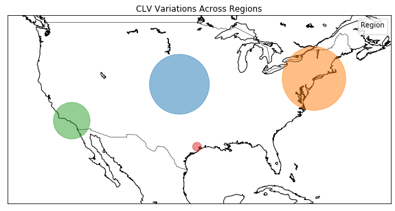

```
No handles with labels found to put in legend.
```

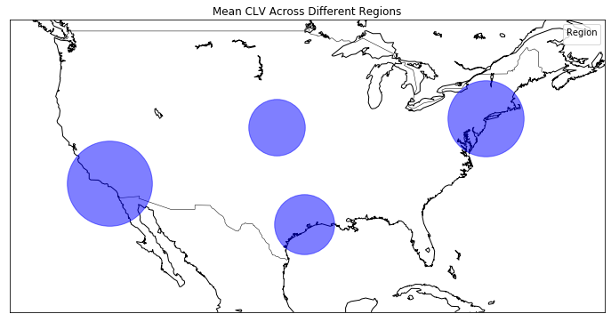

```python
import pandas as pd
import numpy as np
import matplotlib.pyplot as plt
from mpl_toolkits.basemap import Basemap

df = clv_data_filtered.reset_index()

# Define coordinates for each region (replace with actual coordinates if available)
region_coordinates = {
    'Central': (39.8333, -98.5855),
    'East': (40.7128, -74.0060),
    'West': (34.0522, -118.2437),
    'South': (29.7604, -95.3698)
}

# Create Basemap
plt.figure(figsize=(10, 8))
m = Basemap(projection='mill', llcrnrlat=20, urcrnrlat=50, llcrnrlon=-130, urcrnrlon=-60, resolution='l')
m.drawcoastlines()
m.drawcountries()

# Plot CLV variations across regions
for region, coord in region_coordinates.items():
    clv_values = df[df['Region'] == region]['CLV']
    x, y = m(coord[1], coord[0])
    m.scatter(x, y, s=clv_values/100, alpha=0.5, zorder=5)

# Add legend
plt.legend(title='Region')

# Show plot
plt.title('CLV Variations Across Regions')
plt.show()

# Calculate CLV summary statistics for each region
clv_summary = df.groupby('Region')['CLV'].agg(['mean', 'median', 'sum'])

# Plot CLV summaries across regions using Basemap
plt.figure(figsize=(12, 8))
m = Basemap(projection='mill', llcrnrlat=20, urcrnrlat=50, llcrnrlon=-130, urcrnrlon=-60, resolution='l')
m.drawcoastlines()
m.drawcountries()

# Plot regions and color them based on CLV
for region, coord in region_coordinates.items():
    clv_mean = clv_summary.loc[region, 'mean']
    x, y = m(coord[1], coord[0])
    m.scatter(x, y, s=clv_mean/80, c='blue', alpha=0.5, zorder=5)

# Add legend
plt.legend(title='Region')

# Show plot
plt.title('Mean CLV Across Different Regions')
plt.show()
```

# Feature Engineering - remove outliers

There appears to be a few outliers, one extreme outlier on in the Central region, so we are best to remove then so our predictive distribution is not skewed

```
Outliers removed: 17
       Customer_Tenure  Frequency_of_Purchases  Average_Order_Value  \
count       720.000000              720.000000           720.000000
mean        547.594444                2.269444           456.308706
std         348.686974                0.575010           584.537055
min           1.000000                2.000000             2.365500
25%         263.000000                2.000000           107.485250
50%         491.000000                2.000000           277.700000
75%         823.250000                2.000000           562.886125
max        1373.000000                6.000000          6861.749000

                CLV
count  7.200000e+02
mean   5.768720e+05
std    9.253204e+05
min    3.307360e+02
25%    7.806003e+04
50%    2.683933e+05
75%    6.715979e+05
max    1.006794e+07
       Customer_Tenure  Frequency_of_Purchases  Average_Order_Value  \
count       703.000000              703.000000           703.000000
mean        536.311522                2.257468           420.624890
std         344.209431                0.560319           528.473976
min           1.000000                2.000000             2.365500
25%         255.500000                2.000000           105.666333
50%         480.000000                2.000000           263.353000
75%         792.000000                2.000000           528.363433
max        1373.000000                6.000000          6861.749000

                CLV
count  7.030000e+02
mean   4.721473e+05
std    5.805733e+05
min    3.307360e+02
25%    7.246172e+04
50%    2.612107e+05
75%    6.227039e+05
max    3.271225e+06
```

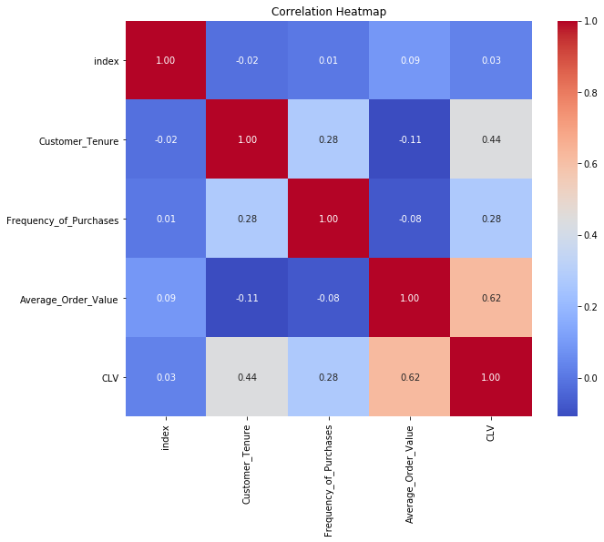

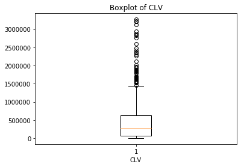

```python
import pandas as pd
import numpy as np

df = clv_data_filtered.reset_index()

# Function to eliminate outliers using Z-score
def remove_outliers_zscore(df, column, threshold=3):
    z_scores = (df[column] - df[column].mean()) / df[column].std()
    df_filtered = df[(z_scores.abs() < threshold)]
    return df_filtered

# Remove outliers from the 'CLV' column using Z-score method
df_filtered = remove_outliers_zscore(df, 'CLV')

# Print the number of outliers removed
outliers_removed = len(df) - len(df_filtered)
print(f'Outliers removed: {outliers_removed}')

# Print the summary statistics of the filtered dataset
print(clv_data_filtered.describe())
print(df_filtered.describe())

clv_data_filtered = df_filtered #Use the dataset with the outliers removed for the predictive algortihm

df = clv_data_filtered.reset_index()

# Correlation matrix
plt.figure(figsize=(10, 8))
sns.heatmap(df.corr(), annot=True, cmap='coolwarm', fmt='.2f')
plt.title('Correlation Heatmap')
plt.show()

# Boxplot for CLV
plt.boxplot(df['CLV'])
plt.xlabel('CLV')
plt.title('Boxplot of CLV')
plt.show()
```

# Check Target Varible Distribution

The CLV variable appears to have many lower value customers and fewer higher value, let normalise the target variable to assist the accuracy of the model fit.

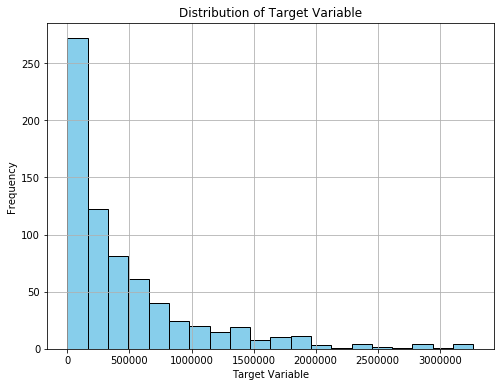

```python
import matplotlib.pyplot as plt

# Plotting the distribution of the target variable
plt.figure(figsize=(8, 6))
plt.hist(clv_data_filtered['CLV'], bins=20, color='skyblue', edgecolor='black')
plt.xlabel('Target Variable')
plt.ylabel('Frequency')
plt.title('Distribution of Target Variable')
plt.grid(True)
plt.show()
```

```python
from sklearn.preprocessing import MinMaxScaler

# Extract the target variable into a separate DataFrame
target_variable = clv_data_filtered[['CLV']]

# Initialize the MinMaxScaler
scaler = MinMaxScaler()

# Fit the scaler to the target variable and transform it
normalized_target = scaler.fit_transform(target_variable)

# Replace the original target variable with the normalized values
clv_data_filtered['CLV_normalized'] = normalized_target

clv_final_test = clv_data_filtered
```

```python
clv_data_filtered
```

|  | Customer_ID | Segment | Region | State | Customer_Tenure | Frequency_of_Purchases | Average_Order_Value | CLV | CLV_normalized |
| --- | --- | --- | --- | --- | --- | --- | --- | --- | --- |
| 0 | AA-10315 | Consumer | West | California | 376 | 2 | 376.754000 | 283319.008 | 0.086517 |
| 1 | AA-10375 | Consumer | West | California | 186 | 2 | 25.396000 | 9447.312 | 0.002787 |
| 2 | AA-10645 | Consumer | West | California | 399 | 2 | 694.702500 | 554372.595 | 0.169385 |
| 3 | AB-10060 | Home Office | West | Washington | 631 | 2 | 1306.964000 | 1649388.568 | 0.504161 |
| 4 | AB-10105 | Consumer | Central | Texas | 664 | 2 | 570.689000 | 757874.992 | 0.231602 |
| ... | ... | ... | ... | ... | ... | ... | ... | ... | ... |
| 715 | YS-21880 | Corporate | West | California | 861 | 3 | 631.561333 | 1631322.924 | 0.498638 |
| 716 | ZC-21910 | Consumer | Central | Illinois | 118 | 2 | 194.029000 | 45790.844 | 0.013898 |
| 717 | ZC-21910 | Consumer | Central | Texas | 319 | 2 | 882.794000 | 563222.572 | 0.172091 |
| 718 | ZC-21910 | Consumer | West | California | 789 | 2 | 470.241000 | 742040.298 | 0.226761 |
| 719 | ZD-21925 | Consumer | West | California | 1167 | 2 | 153.100000 | 357335.400 | 0.109146 |

703 rows × 9 columns

# Create the Training and Test datasets

We're dropping the numerical values and converting our geographical segmentation catergorical variables into numerical variables using one hot encoding

```python
from sklearn.model_selection import train_test_split
from xgboost import XGBRegressor
from sklearn.metrics import mean_squared_error, r2_score

# Perform feature engineering (calculate relevant features)
data = clv_data_filtered.reset_index()

# Split the dataset into features and target variable
X = data[['Segment', 'Region', 'State']] #'Customer_Tenure', 'Frequency_of_Purchases', 'Average_Order_Value']]
y = data['CLV_normalized']

# Encode categorical variables if necessary
X = pd.get_dummies(X)

#X.to_csv("training.csv", index=False)

X
```

|  | Segment_Consumer | Segment_Corporate | Segment_Home Office | Region_Central | Region_East | Region_South | Region_West | State_Arizona | State_California | State_Colorado | ... | State_Ohio | State_Oregon | State_Pennsylvania | State_South Carolina | State_Tennessee | State_Texas | State_Vermont | State_Virginia | State_Washington | State_Wisconsin |
| --- | --- | --- | --- | --- | --- | --- | --- | --- | --- | --- | --- | --- | --- | --- | --- | --- | --- | --- | --- | --- | --- |
| 0 | 1 | 0 | 0 | 0 | 0 | 0 | 1 | 0 | 1 | 0 | ... | 0 | 0 | 0 | 0 | 0 | 0 | 0 | 0 | 0 | 0 |
| 1 | 1 | 0 | 0 | 0 | 0 | 0 | 1 | 0 | 1 | 0 | ... | 0 | 0 | 0 | 0 | 0 | 0 | 0 | 0 | 0 | 0 |
| 2 | 1 | 0 | 0 | 0 | 0 | 0 | 1 | 0 | 1 | 0 | ... | 0 | 0 | 0 | 0 | 0 | 0 | 0 | 0 | 0 | 0 |
| 3 | 0 | 0 | 1 | 0 | 0 | 0 | 1 | 0 | 0 | 0 | ... | 0 | 0 | 0 | 0 | 0 | 0 | 0 | 0 | 1 | 0 |
| 4 | 1 | 0 | 0 | 1 | 0 | 0 | 0 | 0 | 0 | 0 | ... | 0 | 0 | 0 | 0 | 0 | 1 | 0 | 0 | 0 | 0 |
| ... | ... | ... | ... | ... | ... | ... | ... | ... | ... | ... | ... | ... | ... | ... | ... | ... | ... | ... | ... | ... | ... |
| 698 | 0 | 1 | 0 | 0 | 0 | 0 | 1 | 0 | 1 | 0 | ... | 0 | 0 | 0 | 0 | 0 | 0 | 0 | 0 | 0 | 0 |
| 699 | 1 | 0 | 0 | 1 | 0 | 0 | 0 | 0 | 0 | 0 | ... | 0 | 0 | 0 | 0 | 0 | 0 | 0 | 0 | 0 | 0 |
| 700 | 1 | 0 | 0 | 1 | 0 | 0 | 0 | 0 | 0 | 0 | ... | 0 | 0 | 0 | 0 | 0 | 1 | 0 | 0 | 0 | 0 |
| 701 | 1 | 0 | 0 | 0 | 0 | 0 | 1 | 0 | 1 | 0 | ... | 0 | 0 | 0 | 0 | 0 | 0 | 0 | 0 | 0 | 0 |
| 702 | 1 | 0 | 0 | 0 | 0 | 0 | 1 | 0 | 1 | 0 | ... | 0 | 0 | 0 | 0 | 0 | 0 | 0 | 0 | 0 | 0 |

703 rows × 33 columns

# Lets train the model using XGBoost Regressor on Default settings

This enables us to gain a benchmark to compare cross validation and hyperparameter tuning with. It also, as we have chosen to use a tree based model, allows us to extract information gain feature significance from the model.

```
Mean Squared Error: 0.02682879873106989
Coefficient of determination (R^2): -0.059555621098090095
```

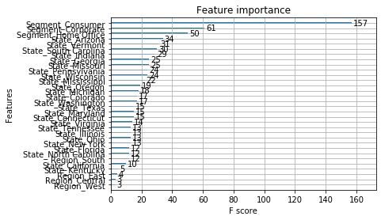

```
Segment_Consumer importance: 0.007213963195681572
Segment_Corporate importance: 0.011572846211493015
Segment_Home Office importance: 0.003374902531504631
Region_Central importance: 0.00024957486311905086
Region_East importance: 0.008717237040400505
Region_South importance: 0.001850860076956451
Region_West importance: 0.5739089250564575
State_Arizona importance: 0.0073021939024329185
State_California importance: 0.06021803244948387
State_Colorado importance: 0.0011379478964954615
State_Connecticut importance: 0.005009836051613092
State_Florida importance: 0.0009614670998416841
State_Georgia importance: 0.007706385105848312
State_Illinois importance: 0.008058098144829273
State_Indiana importance: 0.0012400989653542638
State_Kentucky importance: 0.0002918036771006882
State_Maryland importance: 0.0003257709904573858
State_Michigan importance: 0.002174678025767207
State_Minnesota importance: 0.0
State_Mississippi importance: 0.001906406949274242
State_Missouri importance: 0.004404732491821051
State_New York importance: 0.07880483567714691
State_North Carolina importance: 0.0009502083412371576
State_Ohio importance: 0.0137123242020607
State_Oregon importance: 0.006673610769212246
State_Pennsylvania importance: 0.019747892394661903
State_South Carolina importance: 0.020007984712719917
State_Tennessee importance: 0.0026607403997331858
State_Texas importance: 0.001975724007934332
State_Vermont importance: 0.1150764748454094
State_Virginia importance: 0.001192643423564732
State_Washington importance: 0.029736872762441635
State_Wisconsin importance: 0.0018349607707932591
```

```python
import xgboost as xgb

# Split the data into training and testing sets
X_train, X_test, y_train, y_test = train_test_split(X, y, test_size=0.2, random_state=42)

# Define and train the XGBoost model
model = XGBRegressor()
model.fit(X_train, y_train)

# Make predictions
y_pred = model.predict(X_test)

# Evaluate the model on unseen data
mse = mean_squared_error(y_test, y_pred)
print('Mean Squared Error:', mse)
print('Coefficient of determination (R^2):', r2_score(y_test, y_pred))

# Using feature_importances_ attribute
importances = model.feature_importances_
feature_names = X_train.columns

# Using plot_importance() function
xgb.plot_importance(model)
plt.show()

# Print feature importances
for i in range(len(importances)):
    print(f"{feature_names[i]} importance: {importances[i]}")
```

```python
from sklearn.linear_model import LinearRegression
from sklearn.metrics import mean_squared_error, r2_score
import matplotlib.pyplot as plt

# Training the linear regression model
model_l = LinearRegression()
model_l.fit(X_train, y_train)

# Making predictions
y_pred = model_l.predict(X_test)

# Model evaluation
print('Mean squared error:', mean_squared_error(y_test, y_pred))
print('Coefficient of determination (R^2):', r2_score(y_test, y_pred))
```

```
Mean squared error: 1.5061800699092253e+19
Coefficient of determination (R^2): -5.948389920306329e+20
```

```python
# Load the test predictions dataset
df = pd.read_csv('inference.csv', encoding='latin1')

# check it out...
df
```

|  | Segment_Consumer | Segment_Corporate | Segment_Home Office | Region_Central | Region_East | Region_South | Region_West | State_Arizona | State_California | State_Colorado | ... | State_Ohio | State_Oregon | State_Pennsylvania | State_South Carolina | State_Tennessee | State_Texas | State_Vermont | State_Virginia | State_Washington | State_Wisconsin |
| --- | --- | --- | --- | --- | --- | --- | --- | --- | --- | --- | --- | --- | --- | --- | --- | --- | --- | --- | --- | --- | --- |
| 0 | 1 | 0 | 0 | 0 | 0 | 0 | 1 | 0 | 0 | 0 | ... | 0 | 0 | 0 | 0 | 0 | 0 | 0 | 0 | 1 | 0 |
| 1 | 0 | 1 | 0 | 0 | 0 | 0 | 1 | 0 | 0 | 0 | ... | 0 | 0 | 0 | 0 | 0 | 0 | 0 | 0 | 1 | 0 |
| 2 | 0 | 0 | 1 | 0 | 0 | 0 | 1 | 0 | 0 | 0 | ... | 0 | 0 | 0 | 0 | 0 | 0 | 0 | 0 | 1 | 0 |
| 3 | 1 | 0 | 0 | 0 | 1 | 0 | 0 | 0 | 0 | 0 | ... | 0 | 0 | 1 | 0 | 0 | 0 | 0 | 0 | 0 | 0 |
| 4 | 0 | 1 | 0 | 0 | 1 | 0 | 0 | 0 | 0 | 0 | ... | 0 | 0 | 1 | 0 | 0 | 0 | 0 | 0 | 0 | 0 |
| 5 | 0 | 0 | 1 | 0 | 1 | 0 | 0 | 0 | 0 | 0 | ... | 0 | 0 | 1 | 0 | 0 | 0 | 0 | 0 | 0 | 0 |
| 6 | 1 | 0 | 0 | 1 | 0 | 0 | 0 | 0 | 0 | 0 | ... | 1 | 0 | 0 | 0 | 0 | 0 | 0 | 0 | 0 | 0 |
| 7 | 0 | 1 | 0 | 1 | 0 | 0 | 0 | 0 | 0 | 0 | ... | 1 | 0 | 0 | 0 | 0 | 0 | 0 | 0 | 0 | 0 |
| 8 | 0 | 0 | 1 | 1 | 0 | 0 | 0 | 0 | 0 | 0 | ... | 1 | 0 | 0 | 0 | 0 | 0 | 0 | 0 | 0 | 0 |

9 rows × 33 columns

# Marketing Department want some insight into their next campaign

Marketing have a tight budget and they can only fund two campaigns in two Segments this month, which states should they focus on to entice customers with higher likelihood to spend?

Lets use our model to suggest which Segment marketing should look to market into. Their target states options are Washington, Pennsylvania and Ohio... Looks like Consumer segment in Washington and Home Office segment in Pennsylvania. Its also looks like Home Office in Ohio is a very tough sell!

```python
# Make predictions
y_pred = model.predict(df)

# Convert the normalised CLV back to its original value scale...
CLV_inference = scaler.inverse_transform(y_pred.reshape(-1, 1))

df['CLV_inference'] = CLV_inference

df
```

|  | Segment_Consumer | Segment_Corporate | Segment_Home Office | Region_Central | Region_East | Region_South | Region_West | State_Arizona | State_California | State_Colorado | ... | State_Oregon | State_Pennsylvania | State_South Carolina | State_Tennessee | State_Texas | State_Vermont | State_Virginia | State_Washington | State_Wisconsin | CLV_inference |
| --- | --- | --- | --- | --- | --- | --- | --- | --- | --- | --- | --- | --- | --- | --- | --- | --- | --- | --- | --- | --- | --- |
| 0 | 1 | 0 | 0 | 0 | 0 | 0 | 1 | 0 | 0 | 0 | ... | 0 | 0 | 0 | 0 | 0 | 0 | 0 | 1 | 0 | 958008.125000 |
| 1 | 0 | 1 | 0 | 0 | 0 | 0 | 1 | 0 | 0 | 0 | ... | 0 | 0 | 0 | 0 | 0 | 0 | 0 | 1 | 0 | 391222.250000 |
| 2 | 0 | 0 | 1 | 0 | 0 | 0 | 1 | 0 | 0 | 0 | ... | 0 | 0 | 0 | 0 | 0 | 0 | 0 | 1 | 0 | 497955.718750 |
| 3 | 1 | 0 | 0 | 0 | 1 | 0 | 0 | 0 | 0 | 0 | ... | 0 | 1 | 0 | 0 | 0 | 0 | 0 | 0 | 0 | 187910.093750 |
| 4 | 0 | 1 | 0 | 0 | 1 | 0 | 0 | 0 | 0 | 0 | ... | 0 | 1 | 0 | 0 | 0 | 0 | 0 | 0 | 0 | 371480.062500 |
| 5 | 0 | 0 | 1 | 0 | 1 | 0 | 0 | 0 | 0 | 0 | ... | 0 | 1 | 0 | 0 | 0 | 0 | 0 | 0 | 0 | 689144.687500 |
| 6 | 1 | 0 | 0 | 1 | 0 | 0 | 0 | 0 | 0 | 0 | ... | 0 | 0 | 0 | 0 | 0 | 0 | 0 | 0 | 0 | 170754.843750 |
| 7 | 0 | 1 | 0 | 1 | 0 | 0 | 0 | 0 | 0 | 0 | ... | 0 | 0 | 0 | 0 | 0 | 0 | 0 | 0 | 0 | 467494.437500 |
| 8 | 0 | 0 | 1 | 1 | 0 | 0 | 0 | 0 | 0 | 0 | ... | 0 | 0 | 0 | 0 | 0 | 0 | 0 | 0 | 0 | 51180.132812 |

9 rows × 34 columns

# Lets see how well we are fitting the data

## Cross Validation

Check the likely best results from using default hyperparameter settings to compare to initial trained model.

We have a small dataset so its possible we are overfitting using XGBoost. Our cross validation is worse than the error metrics from the intial test using the default hyperparameters. A significant increase in the data sample would be necessary to determine the very best model for the dataset.

```python
import numpy as np
import pandas as pd
import xgboost as xgb
from sklearn.model_selection import cross_val_score
from sklearn.preprocessing import StandardScaler, OneHotEncoder
from sklearn.compose import ColumnTransformer
from sklearn.pipeline import Pipeline
from sklearn.compose import ColumnTransformer
from sklearn.model_selection import train_test_split

# Load the dataset
df = clv_data_filtered.reset_index()

# Define the features and target variable
features = ['Segment', 'Region', 'State'] #'Customer_Tenure', 'Frequency_of_Purchases', 'Average_Order_Value']
target = 'CLV_normalized'

# Split the data into features (X) and target variable (y)
X = X_train # features
y = y_train # target

# Define the XGBoost model
xgb_regressor = xgb.XGBRegressor()

# Create a pipeline combining the preprocessing steps and the XGBoost model
pipeline = Pipeline(steps=[#('preprocessor', preprocessor),
                           ('model', xgb_regressor)])

# Perform cross-validation with 5 folds
cv_scores = cross_val_score(pipeline, X, y, cv=5, scoring='neg_mean_squared_error')

# Convert the negative mean squared error scores to positive
cv_scores = -cv_scores

# Print the cross-validation scores
print("Cross-validation Mean Squared Error scores:")
print(cv_scores)

# Print the mean and standard deviation of the cross-validation scores
print(f"Mean MSE: {np.mean(cv_scores):.4f} (+/- {np.std(cv_scores):.4f})")
```

```
Cross-validation Mean Squared Error scores:
[0.02050407 0.03170866 0.03756807 0.044575   0.03864562]
Mean MSE: 0.0346 (+/- 0.0081)
```